## Validation of use of Balgzand data on lugworm abundance for inference on *taymyrensis* Bar-Tailed godwit fuelling rates

*internal report by Eldar Rakhimberdiev* You can read this document in [html](http://htmlpreview.github.io/?https://github.com/eldarrak/Godwits_worms_and_climate_change/blob/master/code/Terschelling_Balgzand_SIBES_validation.html?raw=true) or [markdown](https://github.com/eldarrak/Godwits_worms_and_climate_change/blob/master/code/Terschelling_Balgzand_SIBES_validation.rmd)

**Problem description:** In the manuscript I wrote and would like to submit I used data on lugworm abundance from Balgzand to correlate it with fuelling rates of taymyrensis godwits. The question raised at the department is whether it is correct as we know that our godwits are not abundant there as they prefer Terschelling coast Duijns et al. 2009.

**Solution:** SIBES dataset is the only one that covers Terschelling coast, it also covers Balgzand making it possible to directly compare whether the two areas have correlated in time changes in lugworm abundance. Unfortunately SIBES covers only 2008:2014. 2015 and 2016 sampling years are not yet processed.

### Download data

The data are available online till end of December from my Google drive folder.

```r
download.file('https://goo.gl/Jrusw2', 'SIBES.ZIP', mode='wb')
unzip('SIBES.zip')
```

There is Wadden Islands shapefile and two SIBES data files. One with all samples and another one with lugworm data.

### Load required packages:

```r
library(rgdal)
library(rgeos)
```

### Read data

```r
Islands<-readOGR('Islands_Clip.shp')
Points<-read.csv('eldar_sample2008_2015_20161213.csv')
# subset points to include only data before 2015, as 2015 is only partially processed.
Points<-subset(Points, sampleyear<2015)
SpPoints <- SpatialPointsDataFrame(cbind(Points$x, Points$y), Points, proj4string = CRS('+proj=longlat'))

### Reproject to UTM
```

```r
SpPoints_utm<-spTransform(SpPoints, CRS('+proj=utm +zone=30 +datum=WGS84'))
Islands_utm<-spTransform(Islands, CRS('+proj=utm +zone=30 +datum=WGS84'))
```

### Check that data look correct

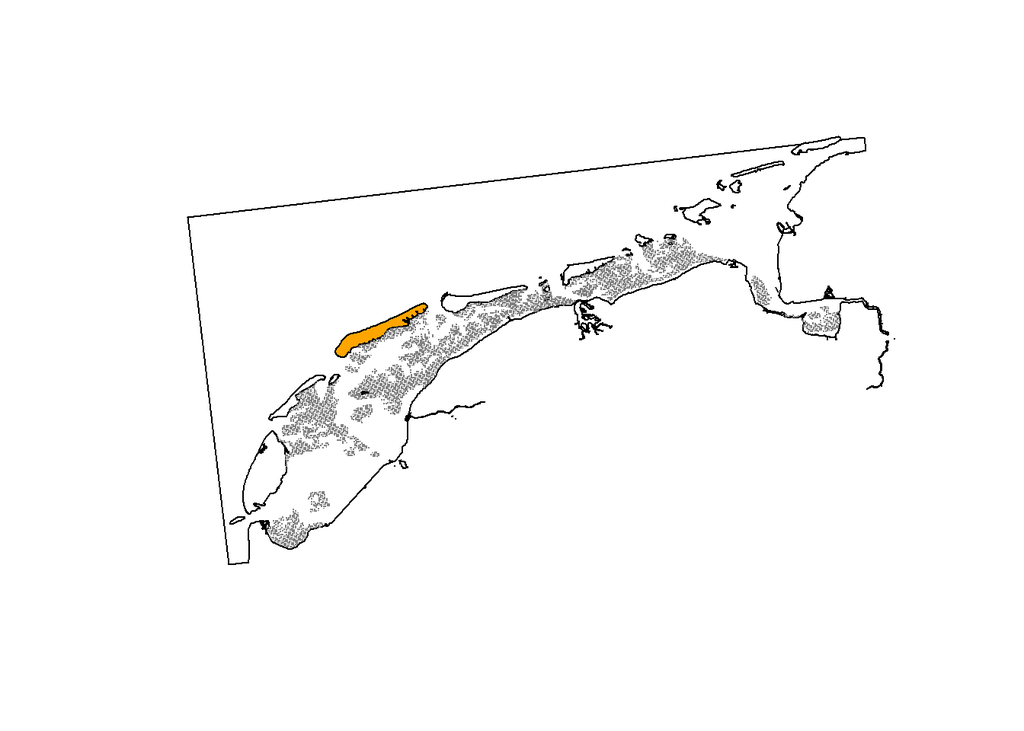

```r
Terschelling_utm<-subset(Islands_utm, landmass=='islands' & SOORT=='Terschelling')
plot(Islands_utm)
plot(Terschelling_utm, add=TRUE, col='orange')
plot(SpPoints_utm, add=TRUE, col=grey(0.5), pch='.')
```

.

### Select SIBES points near (within 500 meters from) Terschelling

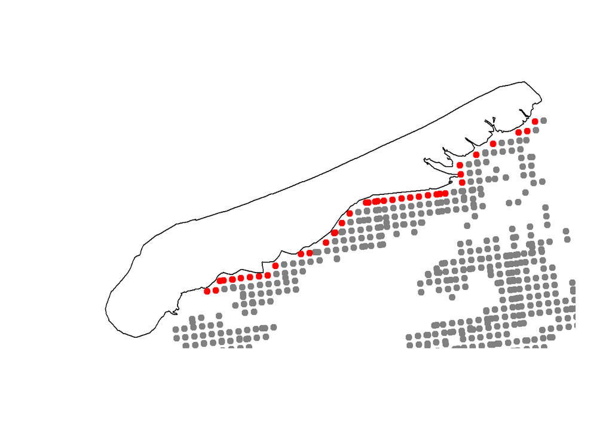

```r
Terschelling_utm<-subset(Islands_utm, landmass=='islands' & SOORT=='Terschelling')
Selected_Points<-gWithinDistance(SpPoints_utm, Terschelling_utm, dist=500, byid=TRUE)
# dist 500 means 500 meters..
plot(Terschelling_utm)
plot(SpPoints_utm, add=TRUE, col=grey(0.5), pch=19)
plot(SpPoints_utm[Selected_Points[1,],], col='red', pch=19, add=TRUE)
```

```r
# extract sample ID for further reference
Sample_id_Terschelling<-SpPoints_utm@data$sample_id[Selected_Points[1,]]
```

### Select Balgzand points

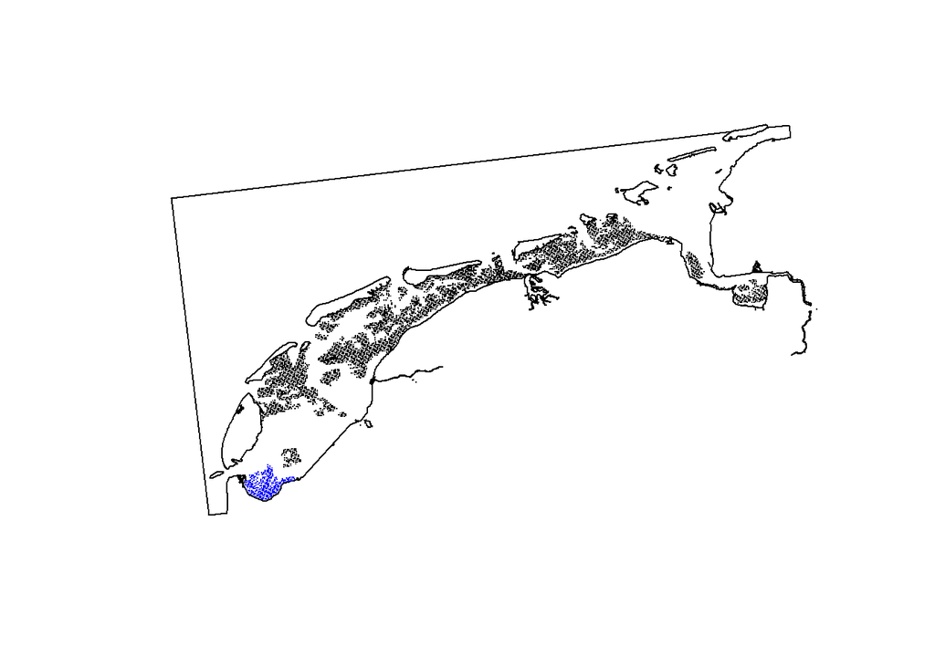

```r
Balzand_utm<-subset(SpPoints_utm, flat_name=='Balgzand')
plot(Islands_utm)
plot(SpPoints_utm, pch='.', add=TRUE)
plot(Balzand_utm, col='blue', pch='.', add=TRUE)
```

### Read lugworm data

```r
Lugworms<-read.csv('eldar_are39_2008_2015_20161213.csv')
Lugworms_ad<-subset(Lugworms, wrm_size==1) # select adult lugworms
```

### Combine selected sampling points with lugworm data

```r
Balgzand_samples_all<-data.frame(Place='B', sample_id=Balzand_utm@data$sample_id,
                                 sampleyear=Balzand_utm@data$sampleyear)
Terschelling_samples_all<-data.frame(Place='T', sample_id=SpPoints_utm@data$sample_id[Selected_Points[1,]],
                                 sampleyear=SpPoints_utm@data$sampleyear[Selected_Points[1,]])
All_count_ad<-rbind(Balgzand_samples_all, Terschelling_samples_all)
Lugworms_count_ad<-(merge(All_count_ad, Lugworms_ad, all.x=TRUE))
Lugworms_count_ad$n_cruc[is.na(Lugworms_count_ad$n_cruc)]<-0
Lugworms_count_ad$n_cruc_ceiling<-ceiling(Lugworms_count_ad$n_cruc)
Lugworms_count_ad_aggr<-aggregate(Lugworms_count_ad$n_cruc_ceiling,
                                  by=list(sample_id=Lugworms_count_ad$sample_id, Place=Lugworms_count_ad$Place,
                                  sampleyear=Lugworms_count_ad$sampleyear), FUN=sum)
```

### Estimate mean by area/year

```r
tmp<-aggregate(Lugworms_count_ad_aggr$x, by=list(sampleyear=Lugworms_count_ad_aggr$sampleyear,
                                                 Place=Lugworms_count_ad_aggr$Place), mean)
Res<-data.frame(sampleyear=2008:2014, Terschelling=subset(tmp, Place=='T')$x/0.01731803,
                Balgzand=subset(tmp, Place=='B')$x/0.01731803) # convert to square meters
```

### Plot results

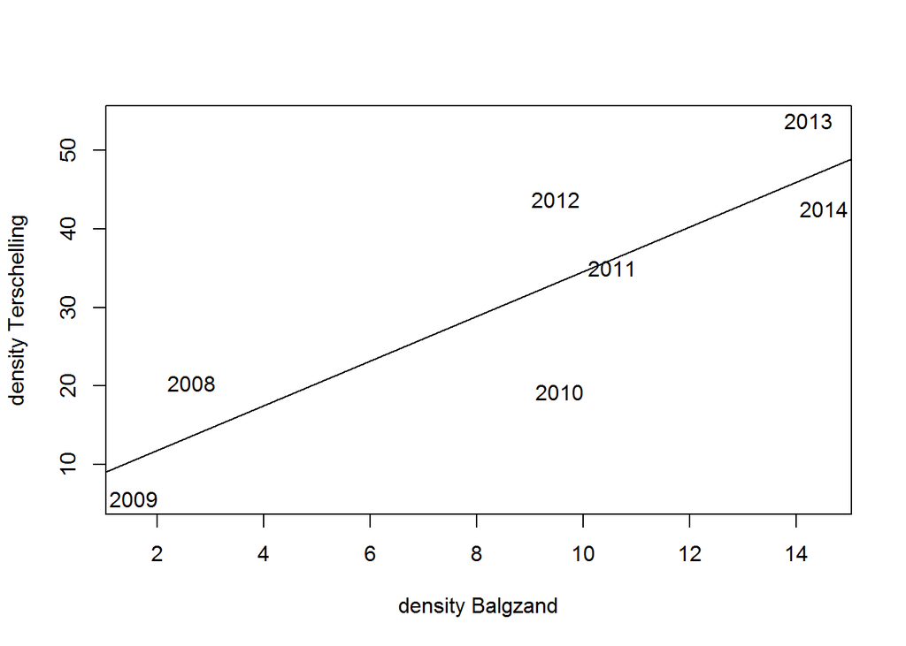

```r
plot(Terschelling~Balgzand, ylab='density Terschelling', xlab='density Balgzand', type='n', data=Res)
text(x=Res$Balgzand, y=Res$Terschelling,  ylab='density Terschelling', xlab='density Balgzand',
     labels=seq(2008,2014))
abline(lm(Terschelling~Balgzand, data=Res))
```

```r
cor.test(subset(tmp, Place=='T')$x,subset(tmp, Place=='B')$x)
```

```
##
##  Pearson's product-moment correlation
##
## data:  subset(tmp, Place == "T")$x and subset(tmp, Place == "B")$x
## t = 3.7205, df = 5, p-value = 0.01371
## alternative hypothesis: true correlation is not equal to 0
## 95 percent confidence interval:
##  0.2934777 0.9785557
## sample estimates:
##       cor
## 0.8571096
```

### Conclusion

From here I conclude that data on Terchelling and Balgzand are highly correlated (Pearson correlation coefficient = 0.86). This means that despite difference between two areas in absolute abundance of lugworms they vary between years in the same way. Another question whether SIBES on Balgzand correlates with Beukema/Dekker sampling in the same place was already answered by Jaap (internal report). He has shown that Pearson correlation coefficient for lugworms for these two sampling schemes is 0.71.

### References

1. Duijns, S. et al. Foraging site delection of two subspecies of bar-tailed godwit *Limosa lapponica*: time minimizers accept greater predation danger than energy minimizers. Ardea 97, 51–59 (2009).

P.S. The html file from this markdown can be recereated with folloing code

```r
download.file('https://git.io/v1SnN', 'Terschelling_Balgzand_SIBES_validation.rmd')
rmarkdown::render('Terschelling_Balgzand_SIBES_validation.rmd', output_format = 'html_document',
        output_options=list(toc=TRUE, toc_float=list(collapsed=FALSE)),
        encoding='utf-8')
```